# R Notebook

# Explore the NOAA Storm Database about severe weather events

### 2019-09-14

## Assignment

The basic goal of this assignment is to explore the NOAA Storm Database and answer some basic questions about severe weather events. You must use the database to answer the questions below and show the code for your entire analysis. Your analysis can consist of tables, figures, or other summaries. You may use any R package you want to support your analysis.

## Synopsis

Storms and other severe weather events can cause both public health and economic problems for communities and municipalities.

This project involves exploring the U.S. National Oceanic and Atmospheric Administration’s (NOAA) storm database. This database tracks characteristics of major storms and weather events in the United States, including when and where they occur, as well as estimates of any fatalities, injuries, and property damage.

The data analysis must address the following questions :

- Across the United States, which types of events (as indicated in the EVTYPE variable) are most harmful with respect to population health ?
- Across the United States, which types of events have the greatest economic consequences ? This analysis shows by aggregating the data by storm events type :

Tornado is the harmful event with respect to population health, and Flood is the event which have the greatest economic consequences.

# Data Processing

```r
# Dowloading data if it's not already done
if(!file.exists("stormData.csv.bz2")) {
  download.file("https://d396qusza40orc.cloudfront.net/repdata%2Fdata%2FStormData.csv.bz2",
  destfile = "stormData.csv.bz2", method = "curl")
}

# Loading data
dsNOAA <- read.csv(bzfile("stormData.csv.bz2"), sep=",", header=T)
head(dsNOAA)
```

```r
# Subset (NOAA) storm database
tidyNOAA <- dsNOAA[,c('EVTYPE','FATALITIES','INJURIES', 'PROPDMG', 'PROPDMGEXP', 'CROPDMG', 'CROPDMGEXP')]
head(tidyNOAA)
str(tidyNOAA)
```

To calculate the economic damage the following variables must be used:

PROPDMG and CROPDMG: Amount (without unit) of property damage and crop damage

PROPDMGEXP and CROPDMGEXP: Unit expressed in power of 10 of the above variables (H,K,M B means Hundreds, Thousands, Millions and Billions respectively)

```r
# Convert H, K, M, B units to calculate Property Damage

## first create an empty column
tidyNOAA$PROPDMGNUM = 0

## fill in the data with correct units
tidyNOAA[tidyNOAA$PROPDMGEXP == "H", ]$PROPDMGNUM = tidyNOAA[tidyNOAA$PROPDMGEXP == "H", ]$PROPDMG * 10^2
tidyNOAA[tidyNOAA$PROPDMGEXP == "K", ]$PROPDMGNUM = tidyNOAA[tidyNOAA$PROPDMGEXP == "K", ]$PROPDMG * 10^3
tidyNOAA[tidyNOAA$PROPDMGEXP == "M", ]$PROPDMGNUM = tidyNOAA[tidyNOAA$PROPDMGEXP == "M", ]$PROPDMG * 10^6
tidyNOAA[tidyNOAA$PROPDMGEXP == "B", ]$PROPDMGNUM = tidyNOAA[tidyNOAA$PROPDMGEXP == "B", ]$PROPDMG * 10^9

head(tidyNOAA, 100)
```

```r
# Convert H, K, M, B units to calculate Crop Damage

## create an empty column
tidyNOAA$CROPDMGNUM = 0

## assign correct values based on parameters
tidyNOAA[tidyNOAA$CROPDMGEXP == "H", ]$CROPDMGNUM = tidyNOAA[tidyNOAA$CROPDMGEXP == "H", ]$CROPDMG * 10^2
tidyNOAA[tidyNOAA$CROPDMGEXP == "K", ]$CROPDMGNUM = tidyNOAA[tidyNOAA$CROPDMGEXP == "K", ]$CROPDMG * 10^3
tidyNOAA[tidyNOAA$CROPDMGEXP == "M", ]$CROPDMGNUM = tidyNOAA[tidyNOAA$CROPDMGEXP == "M", ]$CROPDMG * 10^6
tidyNOAA[tidyNOAA$CROPDMGEXP == "B", ]$CROPDMGNUM = tidyNOAA[tidyNOAA$CROPDMGEXP == "B", ]$CROPDMG * 10^9
```

# Results

Question 1: Across the United States, which types of events (as indicated in the EVTYPE variable) are most harmful with respect to population health ?

Tornado is the most harmful event type as shown in the bar charts

```
Ignoring unknown parameters: las
```

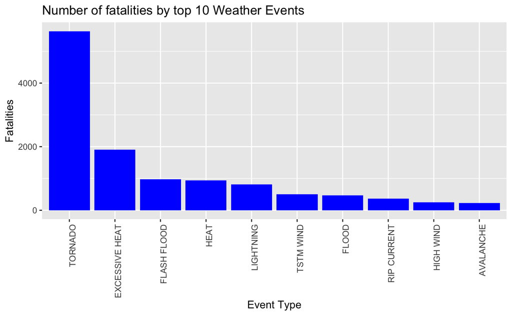

```r
ggplot(fatalities, aes(x = EVTYPE, y = FATALITIES)) +
    geom_bar(stat = "identity", fill = "blue", las = 3) +
    theme(axis.text.x = element_text(angle = 90, hjust = 1)) +
    xlab("Event Type") + ylab("Fatalities") + ggtitle("Number of fatalities by top 10 Weather Events")
```

```
Ignoring unknown parameters: las
```

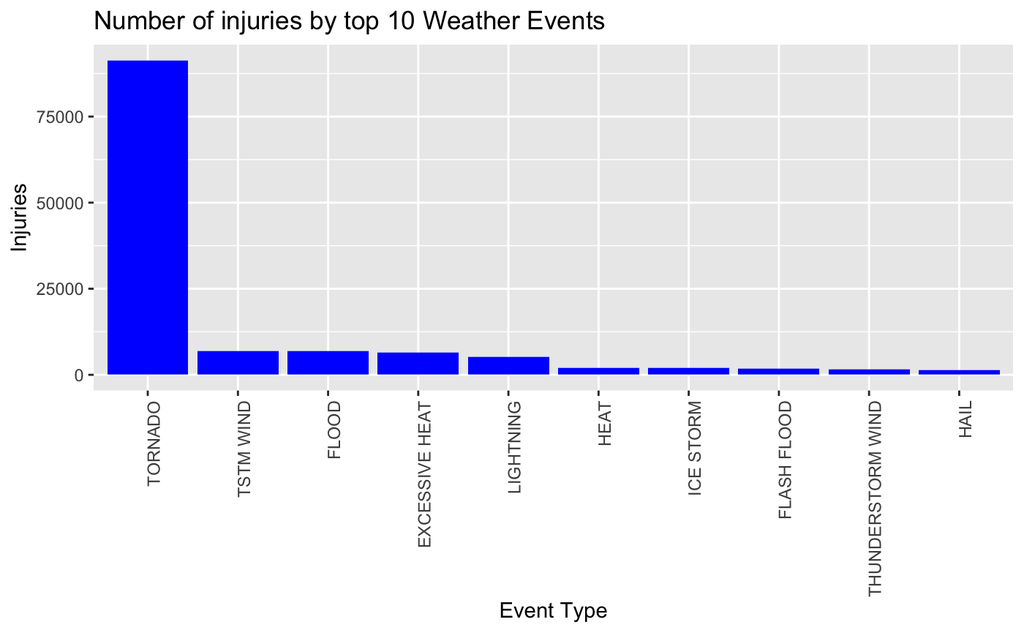

```r
ggplot(injuries, aes(x = EVTYPE, y = INJURIES)) +
    geom_bar(stat = "identity", fill = "blue", las = 3) +
    theme(axis.text.x = element_text(angle = 90, hjust = 1)) +
    xlab("Event Type") + ylab("Injuries") + ggtitle("Number of injuries by top 10 Weather Events")
```

Conclusion: The weather event that causes the most harm to public health is Tornadoes. They have shown in the graphs above to be the largest cause of fatalities and injuries due to weather events in the United States.

Question 2: Across the United States, which types of events hae the greatest economic consequences?

```
Ignoring unknown parameters: las
```

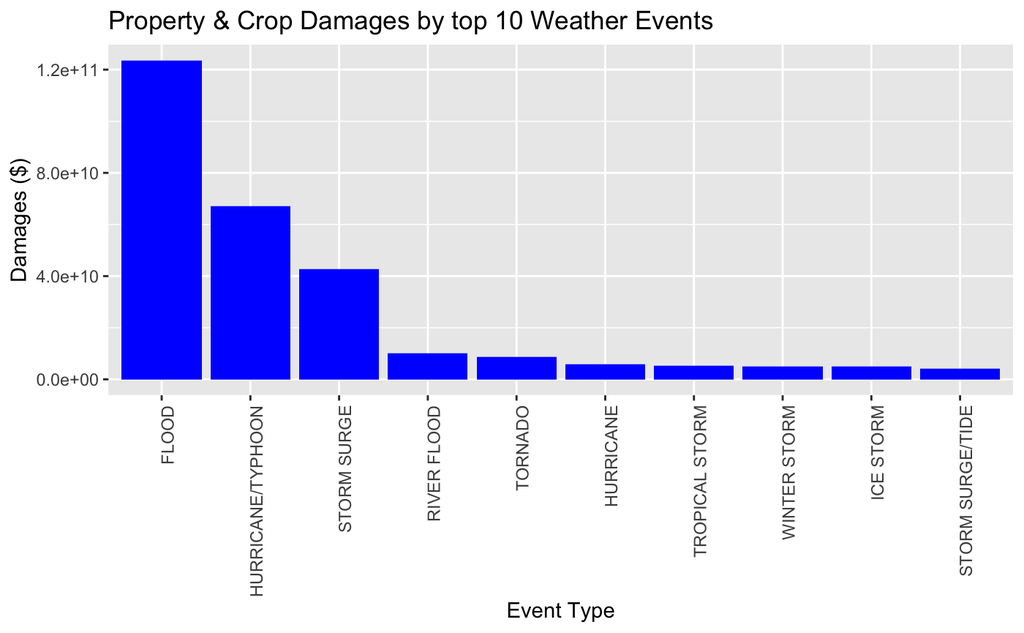

```r
ggplot(damages, aes(x = EVTYPE, y = TOTALDAMAGE)) +
    geom_bar(stat = "identity", fill = "blue", las = 3) +
    theme(axis.text.x = element_text(angle = 90, hjust = 1)) +
    xlab("Event Type") + ylab("Damages ($)") + ggtitle("Property & Crop Damages by top 10 Weather Events")
```